# Hakai Institute Juvenile Salmon Report

Brett Johnson

Wed Sep 11 09:19:31 2019

This analysis is based on the genetic stock ID assigned to sockeye salmon caught in the Discovery Islands and Johnstone Strait in 2015–2017 by the Hakai Institute Juvenile Salmon Program. The stock assignment for sockeye samples is provided by the Molecular Genetics Lab at PBS in Nanaimo.

The analysis uses Hill Numbers 0, 1, 2. Which are unified measures of species richness and Diversity. 0 is Species (stock) richness, 1 is Shannon Diversity, 2 is Simpsons Diversity.

[iNEXT R package user guide](http://chao.stat.nthu.edu.tw/wordpress/wp-content/uploads/software/iNEXT_UserGuide.pdf)

Chao, A., Gotelli, N.J., Hsieh, T.C., Sander, E.L., Ma, K.H., Colwell, R.K. & Ellison, A.M. (2014) Rarefaction and extrapolation with Hill numbers: a framework for sampling and estimation in species diversity studies. Ecological Monographs, 84, 45–67.

# 1 Compare Regions

First lets look at all three years (2015–2017), dates, and sites grouped by regions.

Not constrained to peak migration period

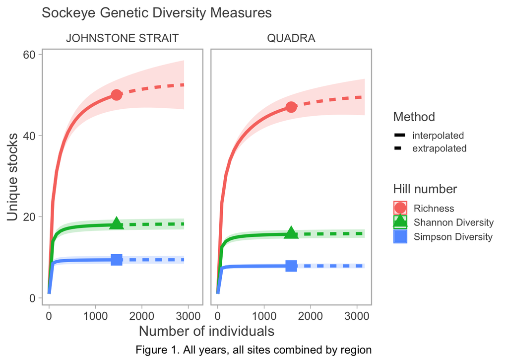

```r
# Start with comparing both regions and entire temporal coverage for all years
all_dna_summary <- dna %>%
   drop_na(stock_1) %>%
   group_by(stock_1, work_area) %>%
   summarize(n = n()) %>%
   spread(key = work_area, value = n) %>%
   replace_na(list(QUADRA = 0, "JOHNSTONE STRAIT" = 0)) %>%
   as.data.frame()

rownames(all_dna_summary) <- all_dna_summary[,1]
all_dna_summary[,1] <- NULL

output_all <- iNEXT(all_dna_summary, q = c(0, 1, 2), datatype = "abundance")

p1 <- ggiNEXT(output_all, type=1, facet.var = "site") +
  ggsidekick::theme_sleek() +
  scale_colour_hakai() +
  ggtitle("Sockeye Genetic Diversity Measures") +
  ylab("Unique stocks") +
  ggsidekick::theme_sleek(base_size = 14)+
  labs(caption = "Figure 1. All years, all sites combined by region")

p2 <- ggiNEXT(output_all, type=2, facet.var = "site") +
  ggsidekick::theme_sleek() +
  scale_colour_hakai() +
  ggtitle("Sample coverage (completeness) curve") +
  ggsidekick::theme_sleek(base_size = 14) +
  labs(caption = "Figure 2. All years, all sites combined by region")

p3 <- ggiNEXT(output_all, type=3, facet.var = "site") +
  ggsidekick::theme_sleek() +
  scale_colour_hakai() +
  ggtitle("Coverage-based rarefaction and extrapolation curves") +
  ggsidekick::theme_sleek(base_size = 14) +
  labs(caption = "Figure 3. All years, all sites combined by region")

hill_labels(p1)
```

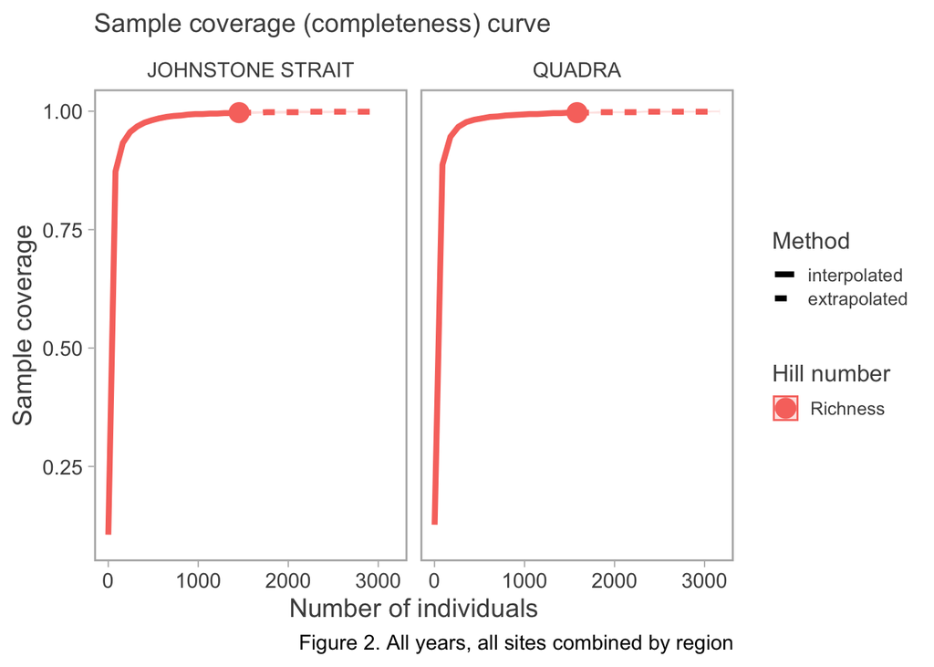

```r
hill_labels(p2)
```

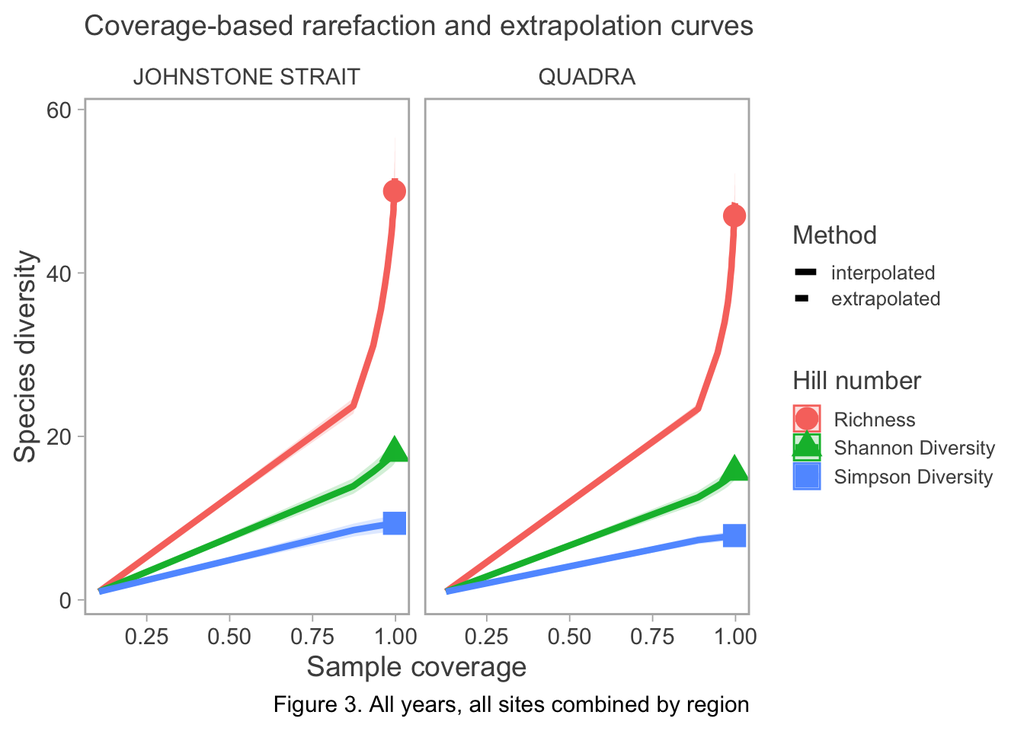

```r
hill_labels(p3)
```

Looks like Johnstone Strait has higher stock richness and diversities compared to Quadra when you very coarsely look at all years and sites combined.

# 2 Compare Discovery Islands Channels

## 2.1 All years combined

Comparing all years combined is not restricted to peak migration period.

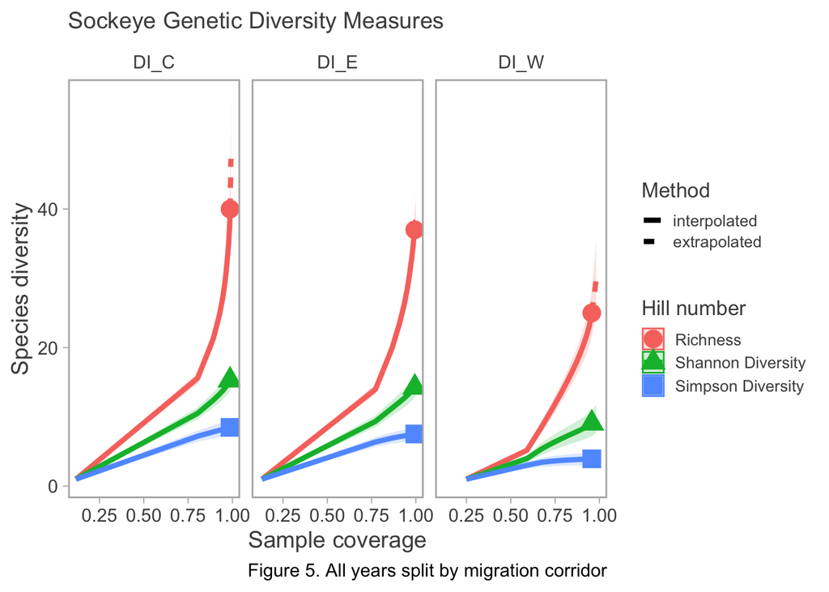

```r
# Bind both data sets together
di_dna <- bind_rows(ethanol_dna, finclip_dna) %>%
  select(fish_id, work_area, survey, date, stock_1, prob_1) %>%
  mutate(stock_1 = toupper(stock_1),
         year = year(date),
         yday = yday(date))

di <- di_dna %>%
   drop_na(stock_1) %>%
  filter(work_area == "QUADRA") %>%
   group_by(stock_1, survey) %>%
  filter(survey != "DI") %>%
   summarize(n = n()) %>%
   spread(key = survey, value = n) %>%
   replace_na(list("DI" = 0, "DI_C" = 0, "DI_E" =  0, "DI_W" =  0)) %>%
  as.data.frame()

rownames(di) <- di[,1]
di[,1] <- NULL

di_output <- iNEXT(di, q = c(0, 1, 2), datatype = "abundance")

di_output[["DataInfo"]][["site"]] <- fct_relevel(di_output[["DataInfo"]][["site"]],
                                                 "DI_W", "DI_C", "DI_E")

p7 <- ggiNEXT(di_output, type=3, facet.var = "site") +
  ggtitle("Sockeye Genetic Diversity Measures") +
  labs(caption = "Figure 5. All years split by migration corridor")

hill_labels(p7)
```

## 2.2 Split by years

The following statistics are sampled from the min and max date range for the 25th and 75th percentile of cumulative catch abundance of sockeye from 2015, 2016, and 2017. May 23 and June 7 are the min and max dates for the Discovery Islands.

### 2.2.1 2015

[figure not shown]

```r
di_dna <- bind_rows(ethanol_dna, finclip_dna) %>%
  select(fish_id, work_area, survey, date, stock_1, prob_1) %>%
  mutate(stock_1 = toupper(stock_1),
         year = year(date),
         yday = yday(date)) %>%
  filter(yday <= 158 & yday >= 143)

di <- di_dna %>%
   drop_na(stock_1) %>%
  filter(work_area == "QUADRA",
         year == 2015) %>%
   group_by(stock_1, survey) %>%
  filter(survey != "DI") %>%
   summarize(n = n()) %>%
   spread(key = survey, value = n) %>%
   replace_na(list("DI" = 0, "DI_C" = 0, "DI_E" =  0, "DI_W" =  0)) %>%
  as.data.frame()

rownames(di) <- di[,1]
di[,1] <- NULL

di_output <- iNEXT(di, q = c(0, 1, 2), datatype = "abundance")

di_output[["DataInfo"]][["site"]] <- fct_relevel(di_output[["DataInfo"]][["site"]],
                                                 "DI_W", "DI_C", "DI_E")

p5 <- ggiNEXT(di_output, type=3, facet.var = "site") +
  ggtitle("2015 Sockeye Genetic Diversity Measures") +
  labs(caption = "Figure 5. All years split by migration corridor")

p6 <- ggiNEXT(di_output, type=2, facet.var = "site") +
  ggtitle("2015 Sockeye Genetic Diversity Measures") +
  labs(caption = "Figure 5. All years split by migration corridor")

hill_labels(p5)
```

[figure not shown]

```r
hill_labels(p6)
```

[figure not shown]

```r
di <- di_dna %>%
   drop_na(stock_1) %>%
  filter(work_area == "QUADRA",
         year == 2016) %>%
   group_by(stock_1, survey) %>%
  filter(survey != "DI") %>%
   summarize(n = n()) %>%
   spread(key = survey, value = n) %>%
   replace_na(list("DI" = 0, "DI_C" = 0, "DI_E" =  0, "DI_W" =  0)) %>%
  as.data.frame()

rownames(di) <- di[,1]
di[,1] <- NULL

di_output <- iNEXT(di, q = c(0, 1, 2), datatype = "abundance")

di_output[["DataInfo"]][["site"]] <- fct_relevel(di_output[["DataInfo"]][["site"]],
                                                 "DI_W", "DI_C", "DI_E")

p5 <- ggiNEXT(di_output, type=3, facet.var = "site") +
  ggtitle("2016 Sockeye Genetic Diversity Measures") +
  labs(caption = "Figure 5. All years split by migration corridor")

hill_labels(p5)
```

### 2.2.2 2017

[figure not shown]

```r
di <- di_dna %>%
   drop_na(stock_1) %>%
  filter(work_area == "QUADRA",
         year == 2017) %>%
   group_by(stock_1, survey) %>%
  filter(survey != "DI") %>%
   summarize(n = n()) %>%
   spread(key = survey, value = n) %>%
   replace_na(list("DI" = 0, "DI_C" = 0, "DI_E" =  0, "DI_W" =  0)) %>%
  as.data.frame()

rownames(di) <- di[,1]
di[,1] <- NULL

di_output <- iNEXT(di, q = c(0, 1, 2), datatype = "abundance")

di_output[["DataInfo"]][["site"]] <- fct_relevel(di_output[["DataInfo"]][["site"]],
                                                 "DI_W", "DI_C", "DI_E")

p5 <- ggiNEXT(di_output, type=3, facet.var = "site") +
  ggtitle("2017 Sockeye Genetic Diversity Measures") +
  labs(caption = "Figure 5. All years split by migration corridor")

hill_labels(p5)
```

DI Central is about 95% coverage in 2017, a little less than before but still good.

Something weird is going on in DI West in 2017

### 2.2.3 Discovery Islands Summary

DI Central and East appear to have higher Diversity than DI west. DI west was not sampled during peak migration period in 2016, and was poorly represented in 2017.

We need to sample 60 sockeye per week in each migration channel between 2 week peak period (May 23 and June 7) to get close to a complete sample coverage.

The current plan permits max of 30 sockeye per migration channel per two weeks. We should double sampling efforts during peak migration period to get close to 100% sample coverage.

I think when we get our first big seine of sockeye, we should collect 60 sockeye per seine for two weeks and we’d be good.

# 3 Johnstone Strait

## 3.1 All Years

Comparing all years combined is not restricted to peak migration period.

[figure not shown]

```r
# Bind both data sets together
js_dna <- bind_rows(ethanol_dna, finclip_dna) %>%
  select(fish_id, work_area, survey, date, stock_1, prob_1) %>%
  mutate(stock_1 = toupper(stock_1),
         year = year(date),
         yday = yday(date))

js <- js_dna %>%
  filter(work_area == "JOHNSTONE STRAIT") %>%
  group_by(stock_1, survey) %>%
   summarize(n = n()) %>%
   spread(key = survey, value = n) %>%
   replace_na(list("JS_N" = 0, "JS_S" = 0)) %>%
  as.data.frame() %>%
  drop_na()

rownames(js) <- js[,1]
js[,1] <- NULL

js_output <- iNEXT(js, q = c(0, 1, 2), datatype = "abundance")

p5 <- ggiNEXT(js_output, type=3, facet.var = "site") +
  ggtitle("2017 Sockeye Genetic Diversity Measures") +
  labs(caption = "Figure 5. All years split North and South")

hill_labels(p5)
```

## 3.2 Split by years

[figure not shown]

```r
js_dna <- bind_rows(ethanol_dna, finclip_dna) %>%
  select(fish_id, work_area, survey, date, stock_1, prob_1) %>%
  mutate(stock_1 = toupper(stock_1),
         year = year(date),
         yday = yday(date)) %>%
  filter(yday <= 169 & yday >= 157)

js <- js_dna %>%
  filter(work_area == "JOHNSTONE STRAIT") %>%
  group_by(stock_1, year(date)) %>%
   summarize(n = n()) %>%
    spread(key = "year(date)", value = n) %>%
   replace_na(list("2015" = 0, "2016" = 0, "2017" = 0)) %>%
  as.data.frame()

js <- js[-nrow(js),1:4]
rownames(js) <- js[,1]
js[,1] <- NULL

js_output <- iNEXT(js, q = c(0, 1, 2), datatype = "abundance")

p5 <- ggiNEXT(js_output, type=3, facet.var = "site") +
  ggtitle("2017 Sockeye Genetic Diversity Measures") +
  labs(caption = "Figure 5. All years split North and South")

hill_labels(p5)
```

[figure not shown]

```r
p5 <- ggiNEXT(js_output, type=2, facet.var = "site") +
  ggtitle("2017 Sockeye Genetic Diversity Measures") +
  labs(caption = "Figure 5. All years split North and South")

hill_labels(p5)
```

### 3.2.1 Johnstone Strait Summary

After the first big seine of sockeye in Johnstone Strait, we need to collect 60 sockeye per seine for 2 weeks.

```r
beepr::beep(8)
```